# Capstone: Bellabeats Fitness Analysis

### Analysis Part 3: Hours with the highest activity levels

Here I will do a similar task to what I’ve done above. This time looking at which hours of the day are most active.

First lets explore our data sets for hourly data.

```r
str(hourly_calories)
```

```
## spc_tbl_ [22,099 × 6] (S3: spec_tbl_df/tbl_df/tbl/data.frame)
##  $ Id          : num [1:22099] 1.5e+09 1.5e+09 1.5e+09 1.5e+09 1.5e+09 ...
##  $ ActivityHour: chr [1:22099] "4/12/16 0:00" "4/12/16 1:00" "4/12/16 2:00" "4/12/16 3:00" ...
##  $ Calories    : num [1:22099] 81 61 59 47 48 48 48 47 68 141 ...
##  $ Date        : chr [1:22099] "4/12/16" "4/12/16" "4/12/16" "4/12/16" ...
##  $ Hour        : 'hms' num [1:22099] 00:00:00 01:00:00 02:00:00 03:00:00 ...
##   ..- attr(*, "units")= chr "secs"
##  $ HourNumber  : num [1:22099] 0 1 2 3 4 5 6 7 8 9 ...
##  - attr(*, "spec")=
##   .. cols(
##   ..   Id = col_double(),
##   ..   ActivityHour = col_character(),
##   ..   Calories = col_double(),
##   ..   Date = col_character(),
##   ..   Hour = col_time(format = ""),
##   ..   HourNumber = col_double()
##   .. )
##  - attr(*, "problems")=<externalptr>
```

Next, I’ll see how many calories on average are burnned each hour.

```r
avg_calories_per_hour <- aggregate(Calories ~ HourNumber, hourly_calories, mean)
avg_calories_per_hour
```

```
##    HourNumber  Calories
## 1           0  71.80514
## 2           1  70.16506
## 3           2  69.18650
## 4           3  67.53805
## 5           4  68.26180
## 6           5  81.70815
## 7           6  86.99678
## 8           7  94.47798
## 9           8 103.33727
## 10          9 106.14286
## 11         10 110.46071
## 12         11 109.80690
## 13         12 117.19740
## 14         13 115.30945
## 15         14 115.73290
## 16         15 106.63716
## 17         16 113.32745
## 18         17 122.75276
## 19         18 123.49227
## 20         19 121.48455
## 21         20 102.35762
## 22         21  96.05635
## 23         22  88.26549
## 24         23  77.59358
```

Let’s visualize the data.

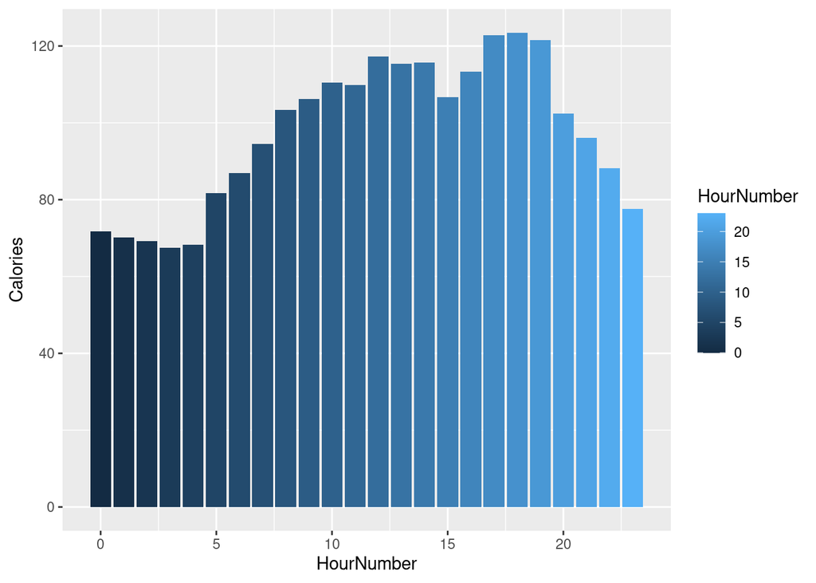

```r
ggplot(avg_calories_per_hour) + geom_col(mapping=aes(x=HourNumber, y=Calories,fill=HourNumber))
```

Here we can see that the most calories are being burnt 17th to 19th hour. in general there is the range 10-19 produces on average a higher amount of calories being burnt, with a significant low at the 15th hour.

Lets analyze the rest of the activity data ina similar way.

```r
avg_steps_per_hour <- aggregate(StepTotal~ HourNumber, hourly_steps, mean)
avg_steps_per_hour
```

```
##    HourNumber  StepTotal
## 1           0  42.188437
## 2           1  23.102894
## 3           2  17.110397
## 4           3   6.426581
## 5           4  12.699571
## 6           5  43.869099
## 7           6 178.508056
## 8           7 306.049409
## 9           8 427.544576
## 10          9 433.301826
## 11         10 481.665231
## 12         11 456.886731
## 13         12 548.642082
## 14         13 537.698154
## 15         14 540.513572
## 16         15 406.319126
## 17         16 496.845645
## 18         17 550.232892
## 19         18 599.169978
## 20         19 583.390728
## 21         20 353.905077
## 22         21 308.138122
## 23         22 237.987832
## 24         23 122.132890
```

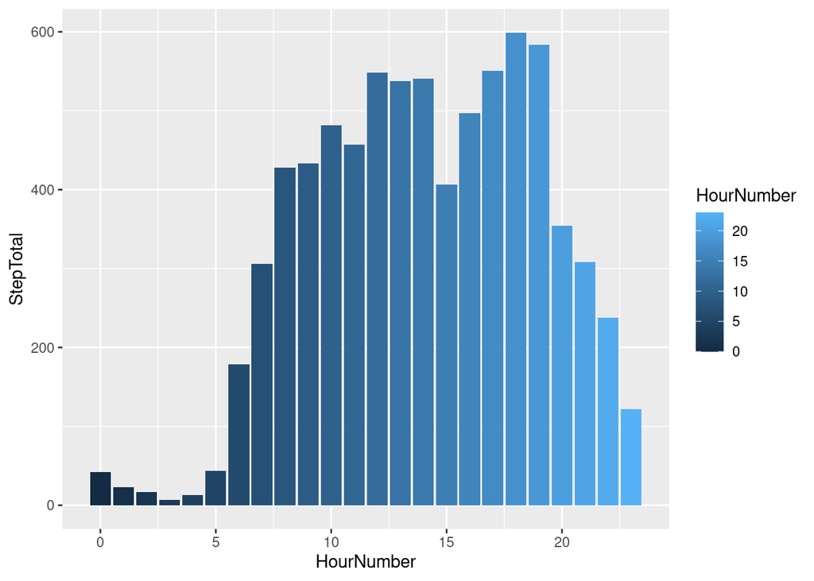

```r
ggplot(avg_steps_per_hour) + geom_col(mapping=aes(x=HourNumber, y=StepTotal,fill=HourNumber))
```

```r
avg_intensity_per_hour <- aggregate(TotalIntensity~ HourNumber, hourly_intensity, mean)
avg_intensity_per_hour
```

```
##    HourNumber TotalIntensity
## 1           0      2.1295503
## 2           1      1.4190782
## 3           2      1.0439443
## 4           3      0.4437299
## 5           4      0.6330472
## 6           5      4.9506438
## 7           6      7.7712137
## 8           7     10.7336198
## 9           8     14.6680988
## 10          9     15.3877551
## 11         10     17.6437029
## 12         11     16.9212513
## 13         12     19.8470716
## 14         13     18.7752443
## 15         14     18.8686211
## 16         15     15.5846995
## 17         16     17.7166483
## 18         17     21.6556291
## 19         18     21.9216336
## 20         19     21.3852097
## 21         20     14.3399558
## 22         21     12.0729282
## 23         22      9.0630531
## 24         23      4.9966777
```

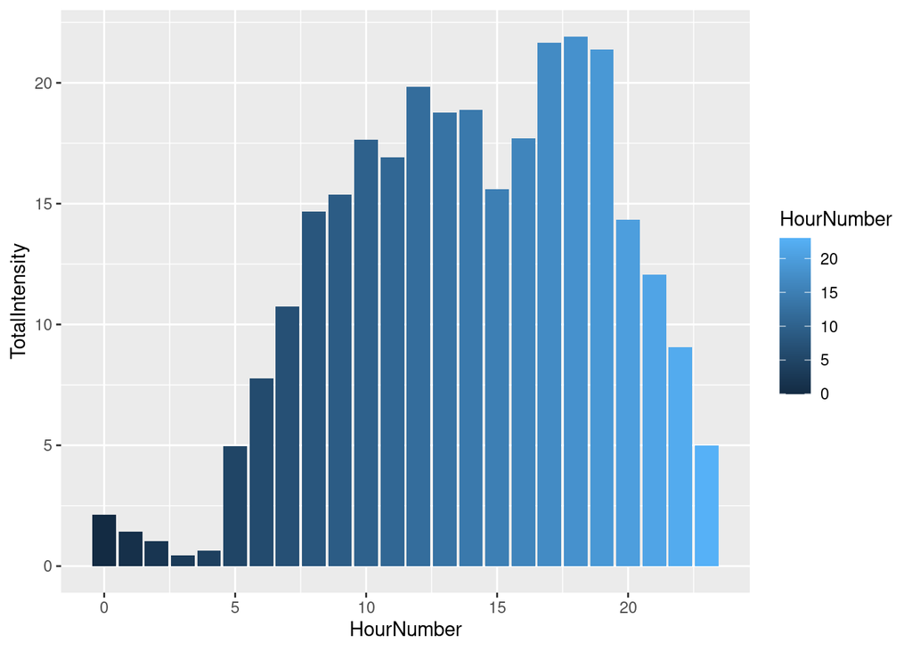

```r
ggplot(avg_intensity_per_hour) + geom_col(mapping=aes(x=HourNumber, y=TotalIntensity,fill=HourNumber))
```

In all categories we see the highest activity level in the 17th - 19th (5:00PM - 7:00Pm) hours of the day. In a wider range we see the activity level 12th - 19th hour (12:00PM - 7:00PM) with a low at the 15th and 16th (3:00PM and 4:00PM) hours.

#### Reccomendation results from Analysis 3

The recommendation would be to focus marketing during the 17th - 19th hour or (5:00PM - 7:00Pm) and 12th - 14th hour (12:00PM - 2:00PM).